# Gradient Boosting

Gradient boosting machines (GBMs) are an extremely popular machine learning algorithm that have proven successful across many domains and is one of the leading methods for winning Kaggle competitions. Whereas random forests build an ensemble of deep independent trees, GBMs build an ensemble of shallow trees in sequence with each tree learning and improving on the previous one. Although shallow trees by themselves are rather weak predictive models, they can be “boosted” to produce a powerful “committee” that, when appropriately tuned, is often hard to beat with other algorithms. This module will cover the fundamentals to understanding and implementing the popular XGBoost implementation of GBMs.

# Learning objectives

By the end of this module you will know:

- What attributes make up gradient boosted machines.
- How to implement an XGBoost gradient boosted tree model along with how to smartly approach hyperparameter tuning.
- How to identify influential features and their effects on the response variable.

# Prerequisites

```python
# Helper packages
import numpy as np
import pandas as pd
from plotnine import *

# Modeling packages
import xgboost as xgb
from sklearn.model_selection import train_test_split
from category_encoders.ordinal import OrdinalEncoder
from sklearn.preprocessing import OneHotEncoder
from sklearn.compose import ColumnTransformer
from sklearn.compose import make_column_selector as selector
from sklearn.compose import ColumnTransformer
from sklearn.compose import make_column_selector as selector
from sklearn.model_selection import KFold
from sklearn.model_selection import cross_val_score
from sklearn.model_selection import GridSearchCV
from sklearn.model_selection import RandomizedSearchCV
from sklearn.inspection import partial_dependence
from sklearn.pipeline import Pipeline
```

```python
# Ames housing data
ames = pd.read_csv("data/ames.csv")

# create train/test split
train, test = train_test_split(ames, train_size=0.7, random_state=123)

# separate features from labels and only use numeric features
X_train = train.drop("Sale_Price", axis=1)
y_train = train[["Sale_Price"]]
```

```r
# Helper packages
library(tidyverse)

# Modeling packages
library(tidymodels)
```

```r
set.seed(123)
ames <- AmesHousing::make_ames()
split  <- rsample::initial_split(ames, prop = 0.7, strata = "Sale_Price")
ames_train  <- rsample::training(split)
ames_test   <- rsample::testing(split)
```

# How boosting works

Several supervised machine learning algorithms are based on a single predictive model, for example: ordinary linear regression, penalized regression models, single decision trees, and support vector machines. Bagging and random forests, on the other hand, work by combining multiple models together into an overall ensemble. New predictions are made by combining the predictions from the individual base models that make up the ensemble (e.g., by averaging in regression). Since averaging reduces variance, bagging (and hence, random forests) are most effectively applied to models with low bias and high variance (e.g., an overgrown decision tree). While boosting is a general algorithm for building an ensemble out of simpler models (typically decision trees), it is more effectively applied to models with high bias and low variance! Although boosting, like bagging, can be applied to any type of model, it is often most effectively applied to decision trees (which we’ll assume from this point on).

## A sequential ensemble approach

The main idea of boosting is to add new models to the ensemble *sequentially*. In essence, boosting attacks the bias-variance-tradeoff by starting with a *weak* model (e.g., a decision tree with only a few splits) and sequentially *boosts* its performance by continuing to build new trees, where each new tree in the sequence tries to fix up where the previous one made the biggest mistakes (i.e., each new tree in the sequence will focus on the training rows where the previous tree had the largest prediction errors); see the image below.

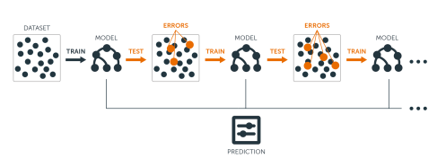

Figure: Sequential ensemble approach.

Let’s discuss the important components of boosting in closer detail.

**The base learners**: Boosting is a framework that iteratively improves *any* weak learning model. Many gradient boosting applications allow you to “plug in” various classes of weak learners at your disposal. In practice however, boosted algorithms almost always use decision trees as the base-learner. Consequently, this module will discuss boosting in the context of decision trees.

**Training weak models**: A weak model is one whose error rate is only slightly better than random guessing. The idea behind boosting is that each model in the sequence slightly improves upon the performance of the previous one (essentially, by focusing on the rows of the training data where the previous tree had the largest errors or residuals). With regards to decision trees, shallow trees (i.e., trees with relatively few splits) represent a weak learner. In boosting, trees with 1–6 splits are most common.

**Sequential training with respect to errors**: Boosted trees are grown sequentially; each tree is grown using information from previously grown trees to improve performance. This is illustrated in the following algorithm for boosting regression trees. By fitting each tree in the sequence to the previous tree’s residuals, we’re allowing each new tree in the sequence to focus on the previous tree’s mistakes:

1. Fit a decision tree to the data: $F_1\left(x\right) = y$,
2. We then fit the next decision tree to the residuals of the previous: $h_1\left(x\right) = y - F_1\left(x\right)$,
3. Add this new tree to our algorithm: $F_2\left(x\right) = F_1\left(x\right) + h_1\left(x\right)$,
4. Fit the next decision tree to the residuals of $F_2$: $h_2\left(x\right) = y - F_2\left(x\right)$,
5. Add this new tree to our algorithm: $F_3\left(x\right) = F_2\left(x\right) + h_2\left(x\right)$,
6. Continue this process until some mechanism (i.e. cross validation) tells us to stop.

The final model here is a stagewise additive model of *b* individual trees:

$$f\left(x\right) = \sum^B_{b=1}f^b\left(x\right) \tag{1}$$

The figure below illustrates with a simple example where a single predictor ($x$) has a true underlying sine wave relationship (blue line) with *y* along with some irreducible error. The first tree fit in the series is a single decision stump (i.e., a tree with a single split). Each successive decision stump thereafter is fit to the previous one’s residuals. Initially there are large errors, but each additional decision stump in the sequence makes a small improvement in different areas across the feature space where errors still remain.

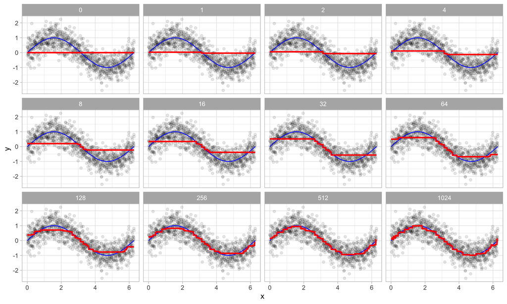

Figure: Boosted regression decision stumps as 0-1024 successive trees are added.

## Gradient descent

Many algorithms in regression, including decision trees, focus on minimizing some function of the residuals; most typically the SSE loss function, or equivalently, the MSE or RMSE (this is accomplished through simple calculus and is the approach taken with least squares). The boosting algorithm for regression discussed in the previous section outlines the approach of sequentially fitting regression trees to the residuals from the previous tree. This specific approach is how gradient boosting minimizes the mean squared error (SSE) loss function (for SSE loss, the gradient is nothing more than the residual error). However, we often wish to focus on other loss functions such as mean absolute error (MAE)—which is less sensitive to outliers—or to be able to apply the method to a classification problem with a loss function such as deviance, or log loss. The name *gradient* boosting machine comes from the fact that this procedure can be generalized to loss functions other than SSE.

Gradient boosting is considered a *gradient descent* algorithm. Gradient descent is a very generic optimization algorithm capable of finding optimal solutions to a wide range of problems. The general idea of gradient descent is to tweak parameter(s) iteratively in order to minimize a cost function. Suppose you are a downhill skier racing your friend. A good strategy to beat your friend to the bottom is to take the path with the steepest slope. This is exactly what gradient descent does—it measures the local gradient of the loss (cost) function for a given set of parameters ($\Theta$) and takes steps in the direction of the descending gradient. As the below figure illustrates, once the gradient is zero, we have reached a minimum.

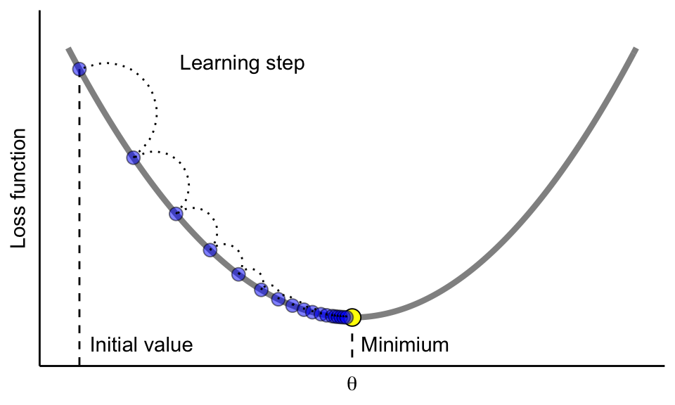

Figure: Gradient descent is the process of gradually decreasing the cost function (i.e. MSE) by tweaking parameter(s) iteratively until you have reached a minimum.

Gradient descent can be performed on any loss function that is differentiable. Consequently, this allows GBMs to optimize different loss functions as desired (see J. Friedman, Hastie, and Tibshirani (2001), p. 360 for common loss functions). An important parameter in gradient descent is the size of the steps which is controlled by the *learning rate*. If the learning rate is too small, then the algorithm will take many iterations (steps) to find the minimum. On the other hand, if the learning rate is too high, you might jump across the minimum and end up further away than when you started.

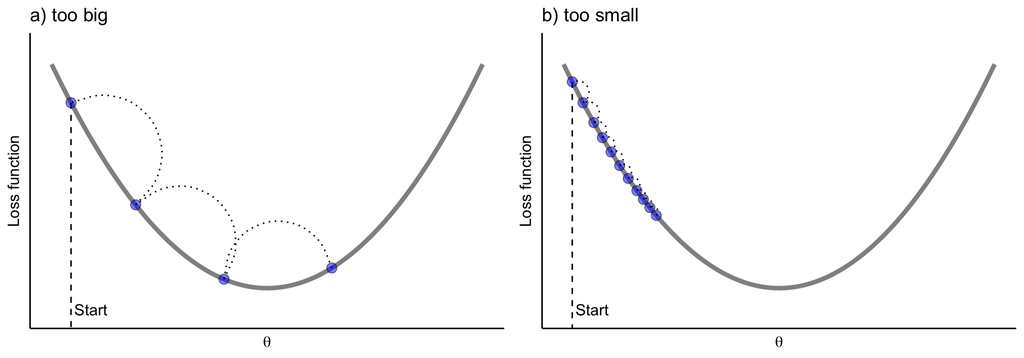

Figure: A learning rate that is too small will require many iterations to find the minimum. A learning rate too big may jump over the minimum.

Moreover, not all cost functions are *convex* (i.e., bowl shaped). There may be local minimas, plateaus, and other irregular terrain of the loss function that makes finding the global minimum difficult. *Stochastic gradient descent* can help us address this problem by sampling a fraction of the training observations (typically without replacement) and growing the next tree using that subsample. This makes the algorithm faster but the stochastic nature of random sampling also adds some random nature in descending the loss function’s gradient. Although this randomness does not allow the algorithm to find the absolute global minimum, it can actually help the algorithm jump out of local minima and off plateaus to get sufficiently near the global minimum.

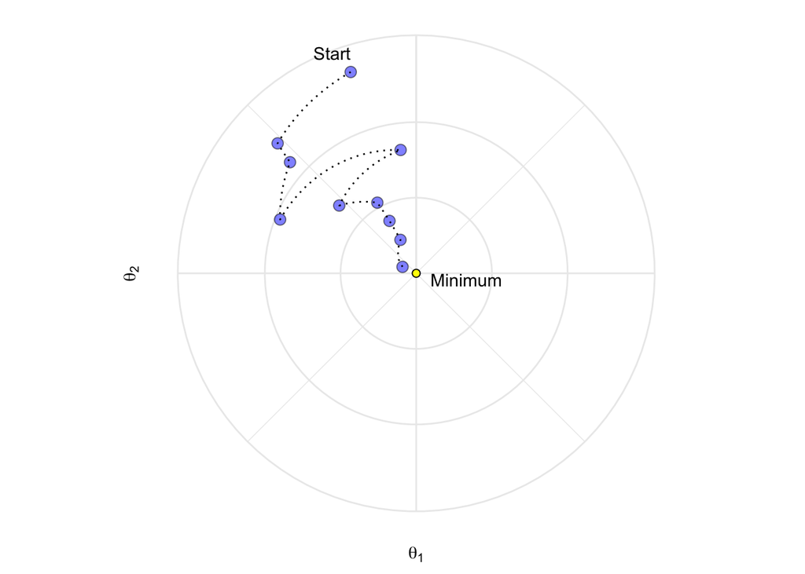

Figure: Stochastic gradient descent will often find a near-optimal solution by jumping out of local minimas and off plateaus.

As we’ll see in the sections that follow, there are several hyperparameter tuning options available in stochastic gradient boosting (some control the gradient descent and others control the tree growing process). If properly tuned (e.g., with *k*-fold CV) GBMs can lead to some of the most flexible and accurate predictive models you can build!

# Basic GBM

There are multiple variants of boosting algorithms with the original focused on classification problems (Kuhn and Johnson 2013). Throughout the 1990’s many approaches were developed with the most successful being the AdaBoost algorithm (Freund and Schapire 1999). In 2000, Friedman related AdaBoost to important statistical concepts (e.g., loss functions and additive modeling), which allowed him to generalize the boosting framework to regression problems and multiple loss functions (J. H. Friedman 2001). This led to the typical GBM model that we think of today and that most modern implementations are built on.

## Hyperparameters

A simple GBM model contains two categories of hyperparameters: *boosting hyperparameters* and *tree-specific hyperparameters*. The two main boosting hyperparameters include:

- **Number of trees**: The total number of trees in the sequence or ensemble. The averaging of independently grown trees in bagging and random forests makes it very difficult to overfit with too many trees. However, GBMs function differently as each tree is grown in sequence to fix up the past tree’s mistakes. For example, in regression, GBMs will chase residuals as long as you allow them to. Also, depending on the values of the other hyperparameters, GBMs often require many trees (it is not uncommon to have many thousands of trees) but since they can easily overfit we must find the optimal number of trees that minimize the loss function of interest with cross validation.
- **Learning rate**: Determines the contribution of each tree on the final outcome and controls how quickly the algorithm proceeds down the gradient descent (learns). Values range from 0–1 with typical values between 0.001–0.3. Smaller values make the model robust to the specific characteristics of each individual tree, thus allowing it to generalize well. Smaller values also make it easier to stop prior to overfitting; however, they increase the risk of not reaching the optimum with a fixed number of trees and are more computationally demanding. This hyperparameter is also commonly referred to as *shrinkage*. Generally, the smaller this value, the more accurate the model can be but also will require more trees in the sequence.

The two main tree hyperparameters in a simple GBM model include:

- **Tree depth**: Controls the depth of the individual trees. Typical values range from a depth of 3–8 but it is not uncommon to see a tree depth of 1 (J. Friedman, Hastie, and Tibshirani 2001). Smaller depth trees such as decision stumps are computationally efficient (but require more trees); however, higher depth trees allow the algorithm to capture unique interactions but also increase the risk of over-fitting. Note that larger $n$ or $p$ training data sets are more tolerable to deeper trees.
- **Minimum number of observations in terminal nodes**: Also, controls the complexity of each tree. Since we tend to use shorter trees this rarely has a large impact on performance. Typical values range from 5–15 where higher values help prevent a model from learning relationships which might be highly specific to the particular sample selected for a tree (overfitting) but smaller values can help with imbalanced target classes in classification problems.

## Implementation

The following implementations will first show you how to apply a basic, default XGBoost model to your data and then we’ll show you how to tune the hyperparameters mentioned in the previous section.

First, similar to the previous modules, we are going to ordinal encode our Quality/Condition features (i.e. `Overall_Qual`, `Garage_Qual`, `Kitchen_Qual`) and, as usual, we need to one-hot encode our remaining nominal features.

```python
# Ordinal encode our quality-based features
ord_cols = list(X_train.filter(regex=("Qual$|QC$|Cond$")).columns)
lvs = ["Very_Poor", "Poor", "Fair", "Below_Average", "Average", "Typical",
       "Above_Average", "Good", "Very_Good", "Excellent", "Very_Excellent"]
val = range(0, len(lvs))
lvl_map = dict(zip(lvs, val))
category_mapping = [{'col': col, 'mapping': lvl_map} for col in ord_cols]
ord_encoder = OrdinalEncoder(cols=ord_cols, mapping=category_mapping)

# one hot encode remaining nominal features
encoder = OneHotEncoder(handle_unknown="ignore", sparse=False)

# combine into a pre-processing pipeline
preprocessor = ColumnTransformer(
  remainder="passthrough",
  transformers=[
   ("ord_encode", ord_encoder, ord_cols),
   ("one-hot", encoder, selector(dtype_include="object")),
   ]
  )
```

To apply a default XGBoost regression model we use `XGBRegressor()` as shown below:

```python
# create GBM estimator
xgb_mod = xgb.XGBRegressor()

# create modeling pipeline
model_pipeline = Pipeline(steps=[
  ("preprocessor", preprocessor),
  ("xgb_mod", xgb_mod),
])

# define loss function
loss = 'neg_root_mean_squared_error'

# create 5 fold CV object
kfold = KFold(n_splits=5, random_state=123, shuffle=True)

# fit model with 5-fold CV
results = cross_val_score(model_pipeline, X_train, y_train, cv=kfold, scoring=loss)

np.abs(np.mean(results))
## 25670.99931790421
```

Due to the many hyperparameters in GBMs it is far more efficient to use a random grid search rather than a full cartesian search. For brevity, in the following example we search across 20 random combinations of number of trees (`n_estimators`), learning rate, max depth, and minimum observations required in nodes (`min_child_weight`).

We see that the optimal model of the random search had an RMSE of 22881 and used 5,000 trees, `min_child_weight` of 1, tree depth of 3, and a learning rate of 0.1.

At this point, it would probably be wise to follow up with another search that uses the `learning_rate`, `max_depth`, and `min_child_weight` of the optimal model but search across additional trees to see if adding more trees improves performance. For brevity we’ll leave this as an exercise for the reader.

```python
# define hyperparameters
hyper_grid = {
  'xgb_mod__n_estimators': [1000, 2500, 5000],
  'xgb_mod__learning_rate': [0.001, 0.01, 0.1],
  'xgb_mod__max_depth': [3, 5, 7, 9],
  'xgb_mod__min_child_weight': [1, 5, 15]
}

# create random search object
random_search = RandomizedSearchCV(
    model_pipeline,
    param_distributions=hyper_grid,
    n_iter=20,
    cv=kfold,
    scoring=loss,
    n_jobs=-1,
    random_state=13
)

# execute random search
random_search_results = random_search.fit(X_train, y_train)

# best model score
np.abs(random_search_results.best_score_)
## 22881.028505504495
```

```python
# best hyperparameter values
random_search_results.best_params_
## {'xgb_mod__n_estimators': 5000, 'xgb_mod__min_child_weight': 1,
## 'xgb_mod__max_depth': 3, xgb_mod__learning_rate': 0.1}
```

First, unlike random forests in R, XGBoost in R requires all features to be numeric. Consequently, we need to ordinal encode our Quality/Condition features (i.e. `Overall_Qual`, `Garage_Qual`, `Kitchen_Qual`) and, as usual, we need to one-hot encode our remaining nominal features. The following recipe follows similar procedures we applied in the feature engineering module.

```r
# create model recipe with all features
lvls <- c("Very_Poor", "Poor", "Fair", "Below_Average", "Average", "Typical",
          "Above_Average", "Good", "Very_Good", "Excellent", "Very_Excellent")

model_recipe <- recipe(
    Sale_Price ~ .,
    data = ames_train
  ) %>%
  step_string2factor(
    ends_with("Qual"), ends_with("QC"), ends_with("_Cond"),
    levels = lvls
    ) %>%
  step_unknown(
    ends_with("Qual"), ends_with("QC"), ends_with("_Cond"),
    new_level = "None"
    ) %>%
  step_relevel(
    ends_with("Qual"), ends_with("QC"), ends_with("_Cond"),
    ref_level = "None"
    ) %>%
  step_integer(ends_with("Qual"), ends_with("QC"), ends_with("_Cond")) %>%
  step_dummy(all_nominal(), one_hot = TRUE)
```

Next, we use `boost_tree()` with the `xgboost` engine to apply a default XGBoost model.

```r
# create XGBost model object
xgb_mod <- boost_tree() %>%
  set_engine("xgboost") %>%
  set_mode("regression")

# create resampling procedure
set.seed(13)
kfold <- vfold_cv(ames_train, v = 5)

# train model
results <- fit_resamples(xgb_mod, model_recipe, kfold)

# model results
collect_metrics(results)
```

```
## # A tibble: 2 x 6
##   .metric .estimator      mean     n    std_err .config
##   <chr>   <chr>          <dbl> <int>      <dbl> <chr>
## 1 rmse    standard   26972.        5 1182.      Preprocessor1_Model1
## 2 rsq     standard       0.888     5    0.00823 Preprocessor1_Model1
```

Due to the many hyperparameters in GBMs it is far more efficient to use a random grid search rather than a full cartesian search. For brevity, in the following example we search across 20 random combinations of number of `trees`, learning rate (`learn_rate`), max depth (`tree_depth`), and minimum observations required in nodes (`min_n`).

Here, we use `parameters()` to extract the hyperparameters we plan to tune in `xgb_mod` and then we use `grid_latin_hypercube` to create our random design.

Read more about working with tidymodel parameters and creating different grid search designs [here](https://www.tmwr.org/grid-search.html#irregular-grids).

```r
# create model object
xgb_mod <- boost_tree(
  trees = tune(),
  learn_rate = tune(),
  tree_depth = tune(),
  min_n = tune()
) %>%
  set_engine("xgboost") %>%
  set_mode("regression")

# create grid search design
hyper_grid <- parameters(xgb_mod) %>%
  grid_latin_hypercube(size = 20)
```

Now we can perform our grid search. We see that the optimal model of the random search had an RMSE of 26752 and used 81 trees, `min_n` of 23, tree depth of 9, and a learning rate of 0.0683.

This grid search takes 40 minutes!

At this point, it would probably be wise to follow up with another search that uses the `learning_rate`, `tree_depth`, and `min_n` of the optimal model but search across additional trees to see if adding more trees improves performance. For brevity we’ll leave this as an exercise for the reader.

```r
# perform grid search
results <- tune_grid(xgb_mod, model_recipe, resamples = kfold, grid = hyper_grid)

# model results
show_best(results, metric = "rmse")
```

```
## # A tibble: 5 x 10
##   trees min_n tree_depth learn_rate .metric .estimator   mean     n std_err
##   <int> <int>      <int>      <dbl> <chr>   <chr>       <dbl> <int>   <dbl>
## 1    81    23          9    0.0683  rmse    standard   26752.     5   2856.
## 2   529    24          7    0.0263  rmse    standard   26923.     5   2849.
## 3  1076    37          2    0.00847 rmse    standard   27461.     5   2667.
## 4  1718     6          6    0.00110 rmse    standard   43209.     5   2171.
## 5   774    31          2    0.00172 rmse    standard   65370.     5   2610.
## # … with 1 more variable: .config <chr>
```

# Stochastic GBMs

An important insight made by Breiman (Breiman (1996); Breiman (2001)) in developing his bagging and random forest algorithms was that training the algorithm on a random subsample of the training data set offered additional reduction in tree correlation and, therefore, improvement in prediction accuracy. J. H. Friedman (2002) used this same logic and updated the boosting algorithm accordingly. This procedure is known as *stochastic gradient boosting* and helps reduce the chances of getting stuck in local minimas, plateaus, and other irregular terrain of the loss function so that we may find a near global optimum.

## Stochastic hyperparameters

There are a few variants of stochastic gradient boosting that can be used, all of which have additional hyperparameters:

- Subsample rows before creating each tree
- Subsample columns before creating each tree
- Subsample columns before creating each level in a tree
- Subsample columns before considering each split in each tree

Generally, aggressive subsampling of rows, such as selecting only 50% or less of the training data, has shown to be beneficial and typical values range between 0.5–0.8. Subsampling of columns and the impact to performance largely depends on the nature of the data and if there is strong multicollinearity or a lot of noisy features. Similar to the $m_{try}$ parameter in random forests, if there are fewer relevant predictors (more noisy data) higher values of column subsampling tends to perform better because it makes it more likely to select those features with the strongest signal. When there are many relevant predictors, a lower values of column subsampling tends to perform well.

When adding in a stochastic procedure you can either include it in the same hyperparameter tuning we did for a basic GBM as in the previous section, or once you’ve found the optimal basic model you can follow it with an additional tuning step and add in stochastic hyperparamters. In our experience, we have not seen strong interactions between the stochastic hyperparameters and the other boosting and tree-specific hyperparameters.

## Implementation

The following takes the best basic GBM model found in the previous section and builds upon it by adding stochastic components. We perform another grid search across the various stochastic parameters available in XGBoost via the Python and R APIs.

In the Python API we will assess the following stochastic parameters: (1) `subsample` rows before each tree and subsampling columns before each tree (`colsample_bytree`), level (`colsample_bylevel`), and split (`colsample_bynode`).

First, we recreate the XBGoost model object and add in the parameter values based on the random search in the previous section. We then apply another random search across 3 values for different stochastic hyperparameters. Again, for brevity, we look at 20 random combinations of these stochastic hyperparameters.

This grid search may take up to 20 minutes!

The results indicate that adding some stochastic elements provides a slight improvement in our results.

```python
# create GBM estimator with previous parameter settings
xgb_mod = xgb.XGBRegressor(
    n_estimators=5000,
    learning_rate=0.1,
    max_depth=3,
    min_child_weight=1
)

# create modeling pipeline
model_pipeline = Pipeline(steps=[
  ("preprocessor", preprocessor),
  ("xgb_mod", xgb_mod),
])

# define stochastic hyperparameters
stochastic_hyper_grid = {
  'xgb_mod__subsample': [0.5, 0.75, 1],
  'xgb_mod__colsample_bytree': [0.5, 0.75, 1],
  'xgb_mod__colsample_bylevel': [0.5, 0.75, 1],
  'xgb_mod__colsample_bynode': [0.5, 0.75, 1]
}

stochastic_random_search = RandomizedSearchCV(
    model_pipeline,
    param_distributions=stochastic_hyper_grid,
    n_iter=20,
    cv=kfold,
    scoring=loss,
    n_jobs=-1,
    random_state=13
)

# execute random search
stochastic_random_search_results = stochastic_random_search.fit(X_train, y_train)

# best model score
np.abs(stochastic_random_search_results.best_score_)
## 21990.50340555188
```

```python
# best hyperparameter values
stochastic_random_search_results.best_params_
## {'xgb_mod__subsample': 1,'xgb_mod__colsample_bytree': 0.75,
## 'xgb_mod__colsample_bynode': 0.75,'xgb_mod__colsample_bylevel': 0.75}
```

In the R API we will assess the following stochastic parameters: (1) subsample rows before each tree (`sample_size`) and (2) subsampling columns before each split (`mtry`).

Similar to what we did in the random forest module, we can pass additional hyperparameters specific to XGBoost by including them in `set_engine()` call.

```r
# create model object
xgb_mod <- boost_tree(
  trees = 81,
  learn_rate = 0.0683,
  tree_depth = 9,
  min_n = 23,
  sample_size = tune(),
  mtry = tune()
) %>%
  set_engine("xgboost") %>%
  set_mode("regression")

# create grid search design and search
# across 10 combinations
hyper_grid <- parameters(xgb_mod) %>%
  update(mtry = finalize(mtry(), ames_train)) %>%
  grid_latin_hypercube(size = 20)
```

This grid search takes only 2 minutes!

```r
# perform grid search
results <- tune_grid(xgb_mod, model_recipe, resamples = kfold, grid = hyper_grid)

# model results
show_best(results, metric = "rmse")
```

```
## # A tibble: 5 x 8
##    mtry sample_size .metric .estimator   mean     n std_err .config
##   <int>       <dbl> <chr>   <chr>       <dbl> <int>   <dbl> <chr>
## 1    66       0.828 rmse    standard   25761.     5   2673. Preproces…
## 2    49       0.698 rmse    standard   25767.     5   2769. Preproces…
## 3    65       0.751 rmse    standard   25812.     5   2813. Preproces…
## 4    78       0.968 rmse    standard   25906.     5   2807. Preproces…
## 5    31       0.778 rmse    standard   26009.     5   2496. Preproces…
```

# Regularized GBMs

XGBoost provides multiple regularization parameters to help reduce model complexity and guard against overfitting.

## Regularization hyperparameters

The first, `gamma`, is a pseudo-regularization hyperparameter known as a Lagrangian multiplier and controls the complexity of a given tree. `gamma` specifies a minimum loss reduction required to make a further partition on a leaf node of the tree. When `gamma` is specified, XGBoost will grow the tree to the max depth specified but then prune the tree to find and remove splits that do not meet the specified `gamma`. `gamma` tends to be worth exploring as your trees in your GBM become deeper and when you see a significant difference between the train and test CV error. The value of `gamma` ranges from $0-\infty$ (0 means no constraint while large numbers mean a higher regularization). What quantifies as a large `gamma` value is dependent on the loss function but generally lower values between 1–20 will do if `gamma` is influential.

Two more traditional regularization parameters include `alpha` and `lambda`. `alpha` provides an $L_1$ regularization (reference [lasso](https://misk-data-science.github.io/misk-homl/docs/notebooks/06-regularized-regression.html#Lasso_penalty)) and `lambda` provides an $L_2$ regularization (reference [ridge](https://misk-data-science.github.io/misk-homl/docs/notebooks/06-regularized-regression.html#Ridge_penalty)). Setting both of these to greater than 0 results in an elastic net regularization; similar to `gamma`, these parameters can range from $0-\infty$. These regularization parameters limits how extreme the weights (or influence) of the leaves in a tree can become.

All three hyperparameters (`gamma`, `alpha`, `lambda`) work to constrain model complexity and reduce overfitting. Although `gamma` is more commonly implemented, your tuning strategy should explore the impact of all three. Below illustrates how regularization can make an overfit model more conservative on the training data which, in some circumstances, can result in improvements to the validation error.

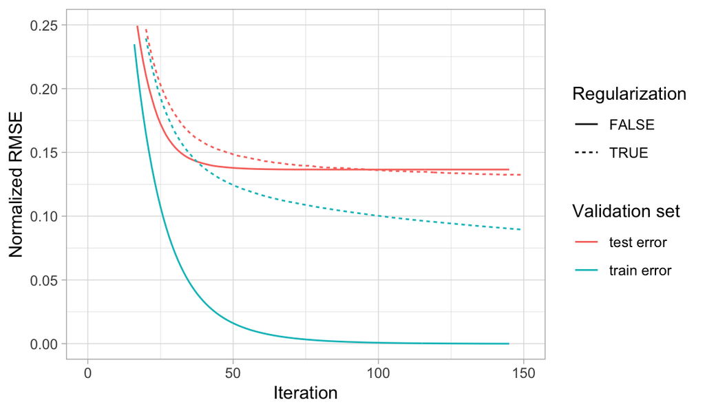

Figure: When a GBM model significantly overfits to the training data (blue), adding regularization (dotted line) causes the model to be more conservative on the training data, which can improve the cross-validated test error (red).

## Implementation

The following illustrates a grid search across various regularization hyperparameter values. First, we recreate the XGBoost model object using the basic and stochastic parameters uncovered in the previous sections. We then search across four different values of the three primary regularization parameters (`gamma`, `alpha`, `lambda`).

When performing the initial search it is best practice to start searching across a logarithmic scale of values. This will often point you to whether low values (i.e. 0.1, 10) are helpful or if very large values of regularization (i.e. 1,000, 10,000) are helpful. It is not uncommon to then follow up with additional grid searches that focus in on more values around that optimal value found in the first grid search.

In this example, regularization does not appear to improve overall performance as we see a slight increase in our RMSE.

This grid search may take up to 20 minutes!

```python
# create stochastic GBM estimator
xgb_mod = xgb.XGBRegressor(
    n_estimators=5000,
    learning_rate=0.1,
    max_depth=3,
    min_child_weight=1,
    subsample=1,
    colsample_bytree=0.75,
    colsample_bylevel=0.75,
    colsample_bynode=0.75
)

# create modeling pipeline
model_pipeline = Pipeline(steps=[
  ("preprocessor", preprocessor),
  ("xgb_mod", xgb_mod),
])

# define regularization hyperparameters
regularization_hyper_grid = {
  'xgb_mod__gamma': [0, 0.1, 10, 1000],
  'xgb_mod__alpha': [0, 0.1, 10, 1000],
  'xgb_mod__lambda': [0, 0.1, 10, 1000]
}

regularization_random_search = RandomizedSearchCV(
    model_pipeline,
    param_distributions=regularization_hyper_grid,
    n_iter=20,
    cv=kfold,
    scoring=loss,
    n_jobs=-1,
    random_state=13
)

# execute random search
regularization_random_search_results = regularization_random_search.fit(X_train, y_train)

# best model score
np.abs(regularization_random_search_results.best_score_)
## 22488.72653394142
```

The following only applies the gamma hyperparameter via `boost_tree`’s `loss_reduction` parameter. Similar to what we did in the random forest module, we could perform a grid search across XGBoost’s `alpha` and `lambda` regularization parameters by passing them in the `set_engine()` call; however, we’ll leave that as a task for the reader.

Similar to the Python example we do not see much improvement by adding regularization.

```r
# create model object
xgb_mod <- boost_tree(
  trees = 81,
  learn_rate = 0.0683,
  tree_depth = 9,
  min_n = 23,
  sample_size = 0.828,
  mtry = 66,
  loss_reduction = tune()
) %>%
  set_engine(
    "xgboost"
    ) %>%
  set_mode("regression")

# create grid of 10 loss_reducton values
hyper_grid <- parameters(xgb_mod) %>%
  grid_regular(levels = 10)

# perform grid search
results <- tune_grid(xgb_mod, model_recipe, resamples = kfold, grid = hyper_grid)

# model results
show_best(results, metric = "rmse")
```

```
## # A tibble: 5 x 7
##   loss_reduction .metric .estimator   mean     n std_err .config
##            <dbl> <chr>   <chr>       <dbl> <int>   <dbl> <chr>
## 1       4.64e- 3 rmse    standard   25568.     5   2681. Preprocessor…
## 2       1   e-10 rmse    standard   25679.     5   2750. Preprocessor…
## 3       3.16e+ 1 rmse    standard   25710.     5   2666. Preprocessor…
## 4       1.90e- 9 rmse    standard   25787.     5   2674. Preprocessor…
## 5       3.59e- 8 rmse    standard   25872.     5   2749. Preprocessor…
```

# Tuning strategy

The general tuning strategy for exploring XGBoost hyperparameters follows:

1. Crank up the number of trees and tune learning rate (with early stopping if possible)
2. Tune tree-specific hyperparameters
3. Explore stochastic GBM attributes
4. If substantial overfitting occurs (e.g., large differences between train and CV error) explore regularization hyperparameters
5. If you find hyperparameter values that are substantially different from default settings, be sure to retune the learning rate
6. Obtain final “optimal” model and re-tune the number of trees.

This strategy follows, generally, the sections previously shown. Consequently, as a final step we can take the final hyperparameter settings found from the previous section and perform one last tuning to ensure the number of trees is optimal.

In this example we see that we actually get the best performance with a lower number of trees. We could actually perform another search that assesses even less number of trees, which could provide compute efficiency. However, we’ll leave that as an exercise for the reader.

```python
# create final GBM estimator
xgb_mod = xgb.XGBRegressor(
    learning_rate=0.1,
    max_depth=3,
    min_child_weight=1,
    subsample=1,
    colsample_bytree=0.75,
    colsample_bylevel=0.75,
    colsample_bynode=0.75
)

# create modeling pipeline
model_pipeline = Pipeline(steps=[
  ("preprocessor", preprocessor),
  ("xgb_mod", xgb_mod),
])

# define hyperparameters
hyper_grid = {'xgb_mod__n_estimators': [2000, 3000, 4000, 5000, 6000, 7000, 8000]}

final_search = GridSearchCV(
    model_pipeline,
    hyper_grid,
    cv=kfold,
    scoring=loss,
    n_jobs=-1
)

# execute search
final_search_results = final_search.fit(X_train, y_train)

# best model score
np.abs(final_search_results.best_score_)
## 21948.509842280964
```

```python
final_search_results.best_params_
## {'xgb_mod__n_estimators': 2000}
```

In the R API we can apply `stop_iter` within our `boost_tree()` call. This allows us to crank up the number of trees to apply but automatically stop if we don’t experience some improvement in the loss for `N` iterations.

In this example we see that we actually get some improvement in our loss by using more trees.

```r
# create model object
xgb_mod <- boost_tree(
  trees = 5000,
  learn_rate = 0.0683,
  tree_depth = 9,
  min_n = 23,
  sample_size = 0.828,
  mtry = 66,
  loss_reduction = 4.64e-3,
  stop_iter = 10
) %>%
  set_engine(
    "xgboost"
    ) %>%
  set_mode("regression")
```

```r
# train model
results <- fit_resamples(xgb_mod, model_recipe, kfold)

# model results
collect_metrics(results)
```

```
## # A tibble: 2 x 6
##   .metric .estimator      mean     n   std_err .config
##   <chr>   <chr>          <dbl> <int>     <dbl> <chr>
## 1 rmse    standard   24674.        5 2130.     Preprocessor1_Model1
## 2 rsq     standard       0.906     5    0.0195 Preprocessor1_Model1
```

# Feature interpretation

Computing feature importance and feature effects for XGBoost models follow the same procedure as discussed in previous modules.

There are multiple ways to compute feature importance with the Python API for XGBoost. Check out this [article](https://mljar.com/blog/feature-importance-xgboost/) for details.

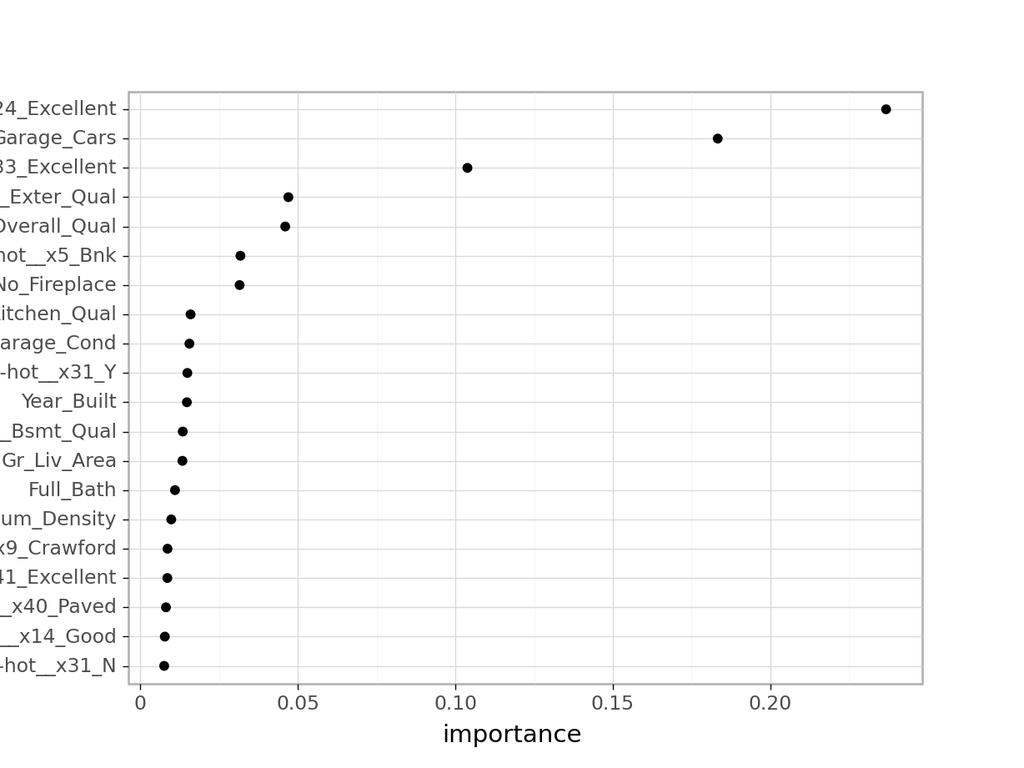

```python
# preprocess training data
X_encoded = preprocessor.fit_transform(X_train)

# create final model object
final_model = xgb.XGBRegressor(
    n_estimators=5000,
    learning_rate=0.1,
    max_depth=3,
    min_child_weight=1,
    subsample=1,
    colsample_bytree=0.75,
    colsample_bylevel=0.75,
    colsample_bynode=0.75
)

final_model_fit = final_model.fit(X_encoded, y_train)

# extract feature importances
vi = pd.DataFrame({'feature': preprocessor.get_feature_names(),
                   'importance': final_model_fit.feature_importances_})

# get top 20 influential features
top_20_features = vi.nlargest(20, 'importance')

# plot feature importance
(ggplot(top_20_features, aes(x='importance', y='reorder(feature, importance)'))
 + geom_point()
 + labs(y=None))
## <ggplot: (327213565)>
```

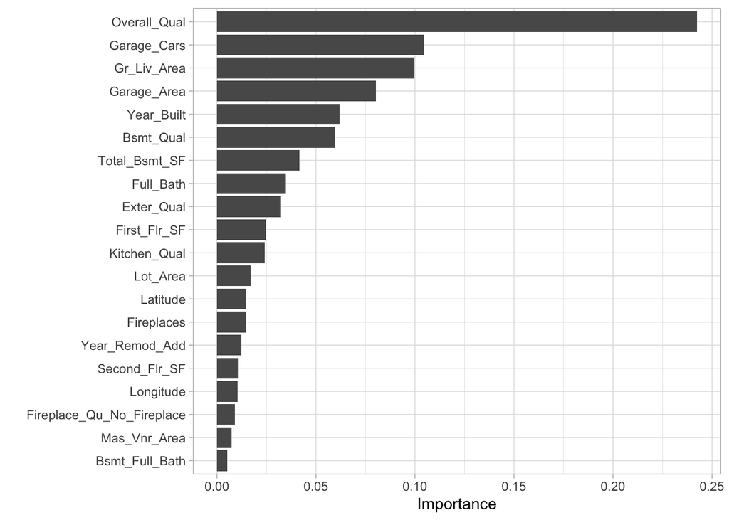

```r
# Create a final fit model
final_fit <- workflow() %>%
  add_recipe(model_recipe) %>%
  add_model(xgb_mod) %>%
  fit(data = ames_train)

# plot top 20 influential variables
final_fit %>%
  pull_workflow_fit() %>%
  vip::vip(num_features = 20)
```

# Final thoughts

GBMs are one of the most powerful ensemble algorithms that are often first-in-class with predictive accuracy. Although they are less intuitive and more computationally demanding than many other machine learning algorithms, they are essential to have in your toolbox.

Although we discussed the most popular GBM algorithms, realize there are alternative algorithms not covered here. For example LightGBM (Ke et al. 2017) is a gradient boosting framework that focuses on *leaf-wise* tree growth versus the traditional level-wise tree growth. This means as a tree is grown deeper, it focuses on extending a single branch versus growing multiple branches. CatBoost (Dorogush, Ershov, and Gulin 2018) is another gradient boosting framework that focuses on using efficient methods for encoding categorical features during the gradient boosting process. Both frameworks are available in Python and R.

# Exercises

Using the Boston housing data set, where the response feature is the median value of homes within a census tract (`cmedv`):

1. Apply a basic GBM model with the same features you used in the random forest module.
   - Apply the default hyperparameter settings with a learning rate set to 0.10. How does model performance compare to the random forest module?
   - How many trees were applied? Was this enough to stabilize the loss function or do you need to add more?
   - Tune the tree-based hyperparameters described for basic GBMs. Did your model performance improve?
2. Apply a stochastic GBM model. Tune the hyperparameters using the suggested tuning strategy for stochastic GBMs. Did your model performance improve?
3. Apply regularization to your XGBoost model. Did regularization improve performance?
4. Pick your best GBM model. Which 10 features are considered most influential? Are these the same features that have been influential in previous models?
5. Create partial dependence plots for the top two most influential features. Explain the relationship between the feature and the predicted values.
6. Now perform 1-5 to the Attrition dataset, which is classification model rather than a regression model.

[🏠](https://github.com/misk-data-science/misk-homl)

# References

Breiman, Leo. 1996. “Bagging Predictors.” *Machine Learning* 24 (2): 123–40.

———. 2001. “Random Forests.” *Machine Learning* 45 (1): 5–32.

Dorogush, Anna Veronika, Vasily Ershov, and Andrey Gulin. 2018. “CatBoost: Gradient Boosting with Categorical Features Support.” *arXiv Preprint arXiv:1810.11363*.

Freund, Yoav, and Robert E Schapire. 1999. “Adaptive Game Playing Using Multiplicative Weights.” *Games and Economic Behavior* 29 (1-2): 79–103.

Friedman, Jerome H. 2001. “Greedy Function Approximation: A Gradient Boosting Machine.” *Annals of Statistics*, 1189–1232.

———. 2002. “Stochastic Gradient Boosting.” *Computational Statistics & Data Analysis* 38 (4): 367–78.

Friedman, Jerome, Trevor Hastie, and Robert Tibshirani. 2001. *The Elements of Statistical Learning*. Vol. 1. Springer Series in Statistics New York, NY, USA:

Ke, Guolin, Qi Meng, Thomas Finley, Taifeng Wang, Wei Chen, Weidong Ma, Qiwei Ye, and Tie-Yan Liu. 2017. “Lightgbm: A Highly Efficient Gradient Boosting Decision Tree.” In *Advances in Neural Information Processing Systems*, 3146–54.

Kuhn, Max, and Kjell Johnson. 2013. *Applied Predictive Modeling*. Vol. 26. Springer.